# EMT Manuscript Figures

### C. Plot the top 50 reactions based on priority score.

```r
# Sort data by priority score
data = data[order(data$`Absolute Effect * N expts`, decreasing=TRUE), ]

# Grab top 50
top50 = data[1:50, ]
```

```r
# Create figures
top50_figures = ko_heatmap(top50)
png(filename="D:/Chandrasekaran/Projects/EMT/Analysis/Figures/COBRA Predictions/RECON1_rxnko_heatmap.png",
       width=20,
       height=12.5,
       units='in',
    res=1200)
top50_figures
dev.off

# Show
top50_figures
```

[output not shown]

```r
# If pathway variable is missing, just visualize everything
data =top50

# Create new data for barplots and discrete heatmap
bardata = data[, 4]
bardata[is.na(bardata)] = 0
expt_data = data[, 5]

# Split by hours
early_data = data[, c("GSE17708_1hrs", "Garcia_1hrs")] - 1
mid1_data  = data[, c("GSE17708_8hrs")] - 1
mid2_data  = data[, c("GSE17708_24hrs", "Garcia_24hrs")] - 1
late_data  = data[, c("GSE17708_72hrs", "GSE17518_72hrs", "Garcia_48hrs",
                                   "Keshamouni_72hrs")] - 1
tmp = cbind(early_data, mid1_data, mid2_data, late_data)

# Create column annotation bars
h1_col = HeatmapAnnotation(h1=anno_block(gp=gpar(fill="#CAC4CE"),
                                    labels=c("1Hr"),
                                    labels_gp=gpar(col="black",
                                                   fontsize=10)))
h2_col = HeatmapAnnotation(h2=anno_block(gp=gpar(fill="#8D86C9"),
                                      labels=c("8Hrs"),
                                      labels_gp=gpar(col="white",
                                                     fontsize=10)))
h3_col = HeatmapAnnotation(h3=anno_block(gp=gpar(fill="#725AC1"),
                                      labels=c("24Hrs"),
                                      labels_gp=gpar(col="white",
                                                     fontsize=10)))
h4_col = HeatmapAnnotation(h4=anno_block(gp=gpar(fill="#242038"),
                                      labels=c("48-72Hrs"),
                                      labels_gp=gpar(col="white",
                                                     fontsize=10)))

# Construct experiment heatmap annotation
hm = Heatmap(as.matrix(expt_data),
         col = colorRamp2(c(1, 2, 3, 4, 5),
                          c("#D8F3DC", "#95D5B2", "#52B788", "#2D6A4F", "#1B4332")),
         heatmap_legend_param=list(title="Experiments",
                                   color_bar="discrete"),
         rect_gp = gpar(col="black",
                          lwd=1),
         width = ncol(expt_data)*unit(5, "mm"),
         height = nrow(expt_data)*unit(5, "mm"))

# Construct priority score barplot annotation
bp = rowAnnotation(
  Priority=anno_barplot(
    bardata
  )
)
# Rows to highlight
myRows = c('L-Glutamine exchange, NA',
           'D-Glucose exchange, NA',
           'pyruvate carboxylase, Pyruvate Metabolism',
           'C160 fatty acid activation, Fatty acid activation',
           'hexokinase (D-glucose:ATP), Glycolysis/Gluconeogenesis',
           'aspartate transaminase, Alanine and Aspartate Metabolism')

# Set stylings for row names and make our selected rows unique
row_idx = which(data$name %in% myRows)
fontcolors = rep('black', nrow(data))
fontcolors[row_idx] = 'red'
fontfaces = rep('plain',nrow(data))
fontfaces[row_idx] = 'bold'
rowAnno = rowAnnotation(rows = anno_text(data$name,
                                       gp = gpar(fontface = fontfaces,
                                                 col = fontcolors),
                                       just='right',
                                       location=1))



# Construct the heatmaps
col_fun = colorRamp2(c(min(as.matrix(tmp)), 0, max(as.matrix(tmp))),
                     c("#E63946", "Gray", "#495057"))
h1 = Heatmap(row_names_side="left",
           early_data,
           col=col_fun,
           cluster_columns=FALSE,
           rect_gp = gpar(col="black",
                          lwd=1),
           cluster_rows=FALSE,
           show_heatmap_legend=FALSE,
           bottom_annotation=h1_col,
           left_annotation = rowAnno,
           width = ncol(early_data)*unit(5, "mm"),
           height = nrow(early_data)*unit(5, "mm"))
```

```
The input is a data frame, convert it to the matrix.
```

```r
h2 = Heatmap(mid1_data,
             col=col_fun,
             cluster_columns=FALSE,
             rect_gp = gpar(col="black",
                            lwd=1),
             cluster_rows=FALSE,
             show_heatmap_legend=FALSE,
             bottom_annotation=h2_col,
             width = ncol(mid1_data)*unit(5, "mm"),
             height = nrow(mid1_data)*unit(5, "mm"))
```

```
The input is a data frame, convert it to the matrix.
```

```r
h3 = Heatmap(mid2_data,
             col=col_fun,
             cluster_columns=FALSE,
             rect_gp = gpar(col="black",
                            lwd=1),
             cluster_rows=FALSE,
             show_heatmap_legend=FALSE,
             bottom_annotation=h3_col,
             width = ncol(mid2_data)*unit(5, "mm"),
             height = nrow(mid2_data)*unit(5, "mm"))
```

```
The input is a data frame, convert it to the matrix.
```

```r
h4 = Heatmap(late_data,
             col=col_fun,
             cluster_columns=FALSE,
             rect_gp = gpar(col="black",
                            lwd=1),
             cluster_rows=FALSE,
             show_heatmap_legend=TRUE,
             bottom_annotation=h4_col,
             width = ncol(late_data)*unit(5, "mm"),
             height = nrow(late_data)*unit(5, "mm"),
             heatmap_legend_param=list(title="Normalized KO Growth Score",
                                     at = c(min(as.matrix(tmp)), 0, max(as.matrix(tmp)))))
```

```
The input is a data frame, convert it to the matrix.
```

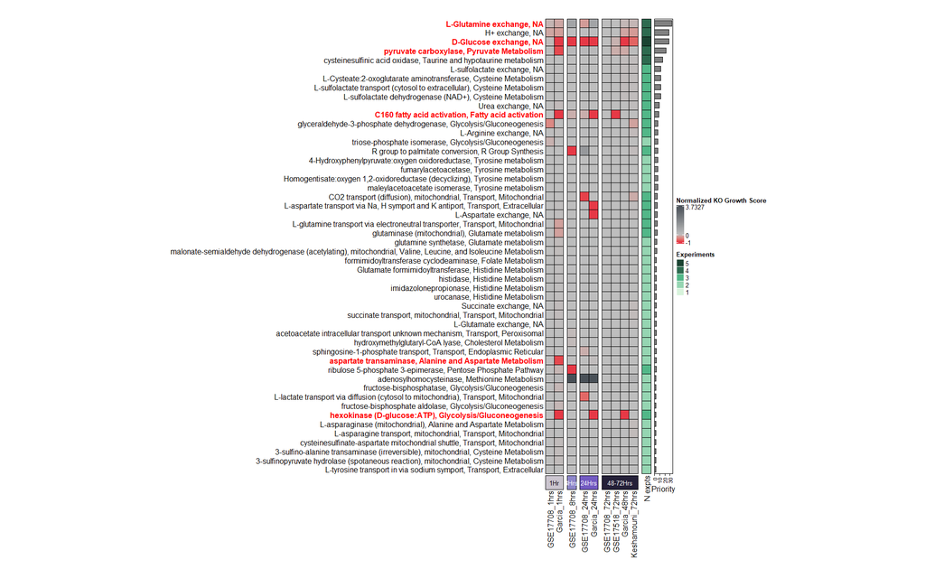

```r
# Return the final figure
final_figure = h1+h2+h3+h4+hm+bp
final_figure
```

Save the top 50 identifiers to get the genes for the CRISPR validation section.

```r
write.csv(top50[, 1:3],
          "D:/Analysis/EMT/data/top50_ko_ids.csv")
```

### D. Grab high confidence reactions (2 or more in same sample)

There’s not that much for high confidence reactions.

```r
# Subset Reactions
reactions_of_interest = c("alpha-ketoglutarate/malate transporter",
                          "carnitine O-acetyltransferase")
idx = data$`BiGG Reaction ID` %in% reactions_of_interest
specific_data = data[idx, ]
```

```r
# Create figures
specific_figures = ko_heatmap(specific_data)
png(filename="D:/Analysis/EMT/figures/RECON1_rxnko_high_priority_heatmap.png",
       width=20,
       height=12.5,
       units='in',
    res=1200)
specific_figures
dev.off()

# Show
specific_figures
```

[output not shown]

Save the high confidence identifiers to get the genes for the CRISPR validation section.

```r
write.csv(specific_data[, 1:3],
          "D:/Analysis/EMT/data/highconf_ko_ids.csv")
```

### E. Grab low confidence reactions (1 in same sample)

The list of low confidence reactions I’d like to visualize is high.

```r
reactions_of_interest = c("alpha-ketoglutarate/malate transporter",
                          "carnitine O-acetyltransferase",
                          'cysteine oxidase',
                          "enolase",
                          "fatty-acyl-CoA elongation (n-C20:4CoA)",
                          "fatty acyl-CoA synthase (n-C10:0CoA)",
                          "fatty-acyl-CoA synthase (n-C12:0CoA)",
                          "fatty-acyl-CoA synthase (n-C14:0CoA)",
                          "hydroxymethylglutaryl-CoA lyase",
                          "dGTP transport via ATP antiport",
                          "UDPglucose 4-epimerase",
                          "adenosine kinase",
                          "pantetheine-phosphate adenylyltransferase",
                          " 4-Hydroxyphenylpyruvate:oxygen oxidoreductase",
                          "fumarylacetoacetase",
                          "Homogentisate:oxygen 1,2-oxidoreductase (decyclizing)",
                          "maleylacetoacetate isomerase",
                          "Malate:sulfite antiport, mitochondrial",
                          "chondroitin 6-sulfotransferase, Golgi apparatus",
                          "nicotinate-nucleotide adenylyltransferase",
                          "malate dehydrogenase",
                          "Norepinephrine uniport",
                          "Hydroxymethylglutaryl-CoA reversible mitochondrial transport",
                          "carnitine-acetylcarnitine carrier, peroxisomal",
                          "carnitine O-acetyltransferase, reverse direction, peroxisomal",
                          "UDP-GlcNAc:betaGal beta-1,3-N-acetylglucosaminyltransferase 1",
                          "UDP-GlcNAc:betaGal beta-1,3-N-acetylglucosaminyltransferase 3, Golgi apparatus",
                          "Hydroxymethylglutaryl CoA synthase (ir)",
                          "citrate transport, mitochondrial",
                          "Aconitate hydratase",
                          "ATP-Citrate lyase",
                          "fumarase, mitochondrial",
                          "triose-phosphate isomerase",
                          "acetone monooxygenase",
                          "fructose-bisphosphatase",
                          "ornithine transaminase reversible (m)",
                          "succinate dehydrogenase",
                          "carnitine O-aceyltransferase, mitochondrial",
                          "citrate synthase",
                          "Isocitrate dehydrogenase (NADP+)",
                          "L-lactate dehydrogenase")
```

Subset and create the plot.

```r
idx = data$`BiGG Reaction ID` %in% reactions_of_interest
specific_data = data[idx, ]
```

```r
# Create figures
specific_figures = ko_heatmap(specific_data)
png(filename="D:/Chandrasekaran/Projects/EMT/Analysis/Figures/COBRA Predictions/RECON1_rxnko_specific_heatmap.png",
       width=20,
       height=12.5,
       units='in',
    res=1200)
specific_figures
dev.off()
```

To make a custom figure for the manuscript:

```r
tmp2 = specific_data
# Rows to delete:
rows_to_delete = c(33, 38)
tmp2 = tmp2[-rows_to_delete, ]

# Create new data for barplots and discrete heatmap
bardata = tmp2[, 4]
bardata[is.na(bardata)] = 0
expt_data = tmp2[, 5]

# Split by hours
early_data = tmp2[, c("GSE17708_1hrs", "Garcia_1hrs")] - 1
mid1_data  = tmp2[, c("GSE17708_8hrs")] - 1
mid2_data  = tmp2[, c("GSE17708_24hrs", "Garcia_24hrs")] - 1
late_data  = tmp2[, c("GSE17708_72hrs", "GSE17518_72hrs", "Garcia_48hrs",
                                   "Keshamouni_72hrs")] - 1
tmp = cbind(early_data, mid1_data, mid2_data, late_data)

# Create column annotation bars
h1_col = HeatmapAnnotation(h1=anno_block(gp=gpar(fill="#CAC4CE"),
                                    labels=c("1Hr"),
                                    labels_gp=gpar(col="black",
                                                   fontsize=10)))
h2_col = HeatmapAnnotation(h2=anno_block(gp=gpar(fill="#8D86C9"),
                                      labels=c("8Hrs"),
                                      labels_gp=gpar(col="white",
                                                     fontsize=10)))
h3_col = HeatmapAnnotation(h3=anno_block(gp=gpar(fill="#725AC1"),
                                      labels=c("24Hrs"),
                                      labels_gp=gpar(col="white",
                                                     fontsize=10)))
h4_col = HeatmapAnnotation(h4=anno_block(gp=gpar(fill="#242038"),
                                      labels=c("48-72Hrs"),
                                      labels_gp=gpar(col="white",
                                                     fontsize=10)))

# Construct experiment heatmap annotation
hm = Heatmap(as.matrix(expt_data),
         col = colorRamp2(c(1, 2, 3, 4, 5),
                          c("#D8F3DC", "#95D5B2", "#52B788", "#2D6A4F", "#1B4332")),
         heatmap_legend_param=list(title="Experiments",
                                   color_bar="discrete"),
         rect_gp = gpar(col="black",
                          lwd=1),
         width = ncol(expt_data)*unit(5, "mm"),
         height = nrow(expt_data)*unit(5, "mm"))

# Construct priority score barplot annotation
bp = rowAnnotation(
  Priority=anno_barplot(
    bardata
  )
)



# Rows to highlight
myRows = c('enolase, Glycolysis/Gluconeogenesis',
           'ATP-Citrate lyase, Citric Acid Cycle',
           'carnitine O-aceyltransferase, mitochondrial, Fatty Acid Metabolism',
           'fatty acyl-CoA synthase (n-C10:0CoA), Fatty acid elongation',
           'fatty-acyl-CoA synthase (n-C12:0CoA), Fatty acid elongation',
           'fatty-acyl-CoA synthase (n-C14:0CoA), Fatty acid elongation',
           'pantetheine-phosphate adenylyltransferase, CoA Biosynthesis',
           'carnitine O-acetyltransferase, Carnitine shuttle',
           'alpha-ketoglutarate/malate transporter, Transport, Mitochondrial',
           'Aconitate hydratase, Citric Acid Cycle',
           'Isocitrate dehydrogenase (NADP+), Citric Acid Cycle',
           'L-lactate dehydrogenase, Glycolysis/Gluconeogenesis',
           'malate dehydrogenase, Citric Acid Cycle'
           )

# Set stylings for row names and make our selected rows unique
row_idx = which(tmp2$name %in% myRows)
fontcolors = rep('black', nrow(tmp2))
fontcolors[row_idx] = 'red'
fontfaces = rep('plain',nrow(tmp2))
fontfaces[row_idx] = 'bold'
rowAnno = rowAnnotation(rows = anno_text(tmp2$name,
                                         gp = gpar(fontface = fontfaces,
                                                   col = fontcolors),
                                         just='right',
                                         location=1))

# Construct the heatmaps
col_fun = colorRamp2(c(min(as.matrix(tmp)), -0.005, 0, 0.03),
                     c("#E63946", "#F1959B", "Gray", "#3E3B39"))
h1 = Heatmap(row_names_side="left",
             early_data,
             col=col_fun,
             cluster_columns=FALSE,
             rect_gp = gpar(col="black",
                            lwd=1),
             cluster_rows=FALSE,
             show_heatmap_legend=FALSE,
             bottom_annotation=h1_col,
             left_annotation = rowAnno,
             width = ncol(early_data)*unit(5, "mm"),
             height = nrow(early_data)*unit(5, "mm"))
```

```
The input is a data frame, convert it to the matrix.
```

```r
h2 = Heatmap(mid1_data,
             col=col_fun,
             cluster_columns=FALSE,
             rect_gp = gpar(col="black",
                            lwd=1),
             cluster_rows=FALSE,
             show_heatmap_legend=FALSE,
             bottom_annotation=h2_col,
             width = ncol(mid1_data)*unit(5, "mm"),
             height = nrow(mid1_data)*unit(5, "mm"))
```

```
The input is a data frame, convert it to the matrix.
```

```r
h3 = Heatmap(mid2_data,
             col=col_fun,
             cluster_columns=FALSE,
             rect_gp = gpar(col="black",
                            lwd=1),
             cluster_rows=FALSE,
             show_heatmap_legend=FALSE,
             bottom_annotation=h3_col,
             width = ncol(mid2_data)*unit(5, "mm"),
             height = nrow(mid2_data)*unit(5, "mm"))
```

```
The input is a data frame, convert it to the matrix.
```

```r
h4 = Heatmap(late_data,
             col=col_fun,
             cluster_columns=FALSE,
             rect_gp = gpar(col="black",
                            lwd=1),
             cluster_rows=FALSE,
             show_heatmap_legend=TRUE,
             bottom_annotation=h4_col,
             width = ncol(late_data)*unit(5, "mm"),
             height = nrow(late_data)*unit(5, "mm"),
             heatmap_legend_param=list(title="Normalized KO Growth Score",
                                     at = c(min(as.matrix(tmp)), 0, max(as.matrix(tmp)))))
```

```
The input is a data frame, convert it to the matrix.
```

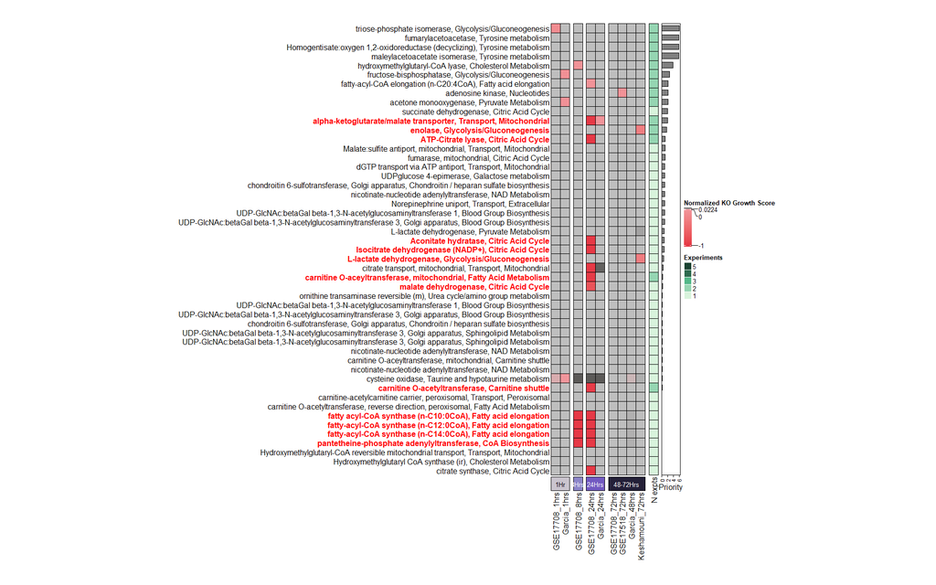

```r
# Return the final figure
final_figure = h1+h2+h3+h4+hm+bp
final_figure
```

```r
# Create figures
png(filename="D:/Chandrasekaran/Projects/EMT/Analysis/Figures/COBRA Predictions/RECON1_rxnko_specific_heatmap.png",
       width=20,
       height=12.5,
       units='in',
    res=1200)
final_figure
dev.off()
```

Save the low confidence identifiers to get the genes for the CRISPR validation section.

```r
write.csv(specific_data[, 1:3],
          "D:/Analysis/EMT/data/lowconf_ko_ids.csv")
```

## 3. Single-Cell Reaction KOs

Finally, let’s create a visualization for the single-cell reaction knockouts.

```r
rm(list=ls())
```

### A. Load Data

```r
filename = "D:/Chandrasekaran/Projects/EMT/Analysis/data/scRNASeq Reaction KO.csv"
data = read_csv(filename)
# Create new variable for row names
data$name = paste0(data$`BiGG Reaction ID`,
                    ', ',
                    data$`KEGG Subsystem`)
```

### B. Subset the average data columns

The data has already been averaged across all cells.

```r
data = data[order(data[, "Std_All"], decreasing=TRUE), ]
tmp = data[, c("Average_All",   "Average_Day0",
               "Average_Hour8", "Average_Day1",
               "Average_Day3",  "Average_Day7")]
tmp = tmp-1
colnames(tmp) = c("Average", "Day 0", "8 Hrs", "Day 1", "Day 3", "Day 7")
names(data)[names(data) == "Std_all"] = "S.D."
```

### C. Create an annotation heatmap showing the average standard deviation for each reaction across all cells

```r
hm = Heatmap(as.matrix(data[, "S.D."]),
             rect_gp = gpar(col = "black",
                            lwd = 1),
             col = colorRamp2(c(0, 0.3),
                              c("#808080", "orange")),
             cluster_columns=FALSE,
             cluster_rows=FALSE,
             heatmap_legend_param=list(title="Average Std",
                                       color_bar="continuous"),
             width = ncol(data[, "S.D."])*unit(5, "mm"),
             height = nrow(data[, "S.D."])*unit(5, "mm"))
```

### D. Create the Heatmap with additional figures

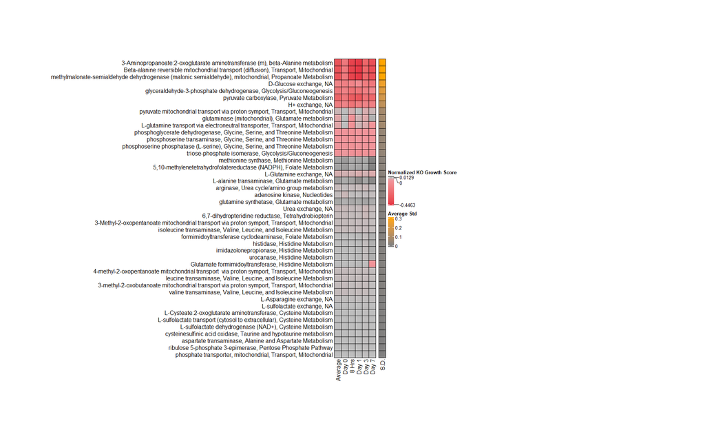

```r
final_data = as.matrix(tmp)
col_fun = colorRamp2(c(min(as.matrix(tmp)), -0.05, 0, 0.03),
                     c("#E63946", "#F1959B", "Gray", "#3E3B39"))

ht = Heatmap(row_labels=data$name,
             final_data,
             row_names_side="left",
             rect_gp = gpar(col = "black",
                            lwd = 1),
             cluster_columns=FALSE,
             cluster_rows=FALSE,
             col = col_fun,
             heatmap_legend_param=list(title="Normalized KO Growth Score",
                                       at = c(min(as.matrix(tmp)), 0, round(max(as.matrix(tmp)), 4))),
             width = ncol(final_data)*unit(5, "mm"),
             height = nrow(final_data)*unit(5, "mm")) + hm

ht
```

Save figures

```r
png(filename="D:/Chandrasekaran/Projects/EMT/Analysis/Figures/COBRA Predictions/scRNASeq_avg_rxn_ko.png",
       width=20,
       height=12.5,
       units='in',
    res=1200)
ht
dev.off()
```

```r
write.csv(data[, 1:3],
          "D:/Analysis/EMT/data/singlecell_ko_ids.csv")
```

## 4. Glycolysis Expression Matrix